# Batch48-PHD ----------Sales Forecasting of Retail Clothing Product Categories using Regression Ananlysis----------

Checking for Outliers in the data

```
 Standard Deviation of Temp high (°C)
```

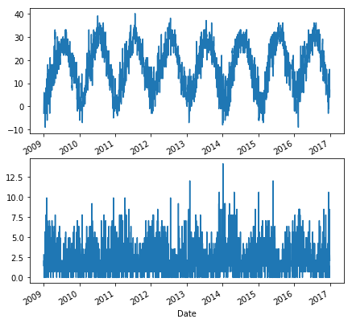

```
 Standard Deviation of Temp avg (°C)
```

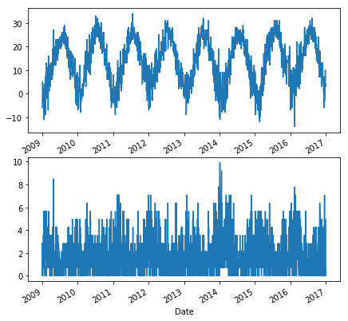

```
 Standard Deviation of Temp low (°C)
```

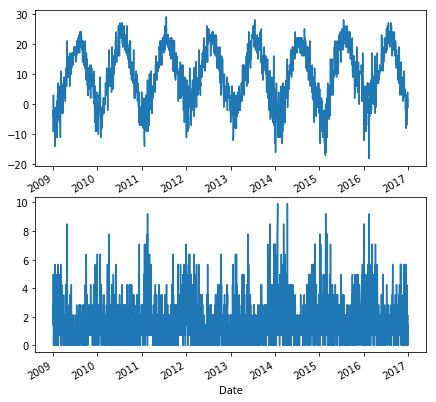

```
 Standard Deviation of Dew Point high (°C)
```

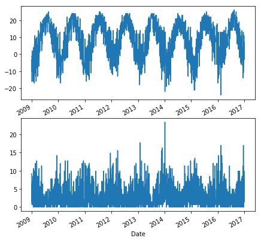

```
 Standard Deviation of Dew Point avg (°C)
```

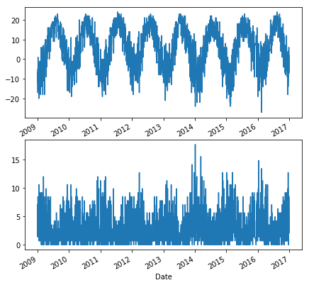

```
 Standard Deviation of Dew Point low (°C)
```

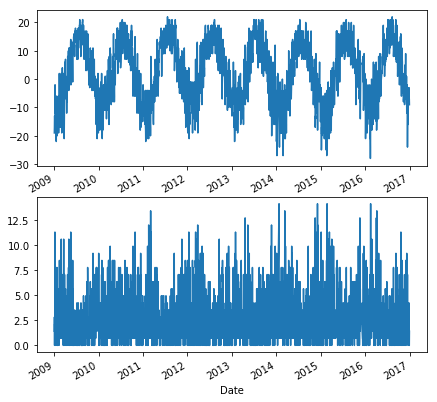

```
 Standard Deviation of Humidity (%) high
```

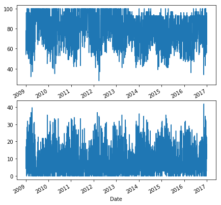

```
 Standard Deviation of Humidity (%) avg
```

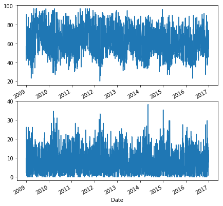

```
 Standard Deviation of Humidity (%) low
```

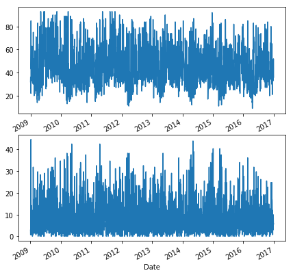

```
 Standard Deviation of Sea Level Press. (hPa) high
```

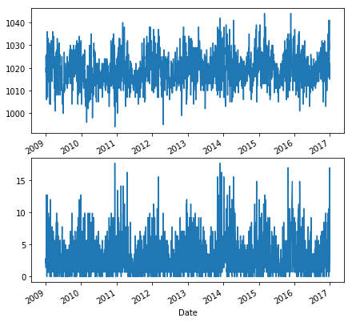

```
 Standard Deviation of Sea Level Press. (hPa) avg
```

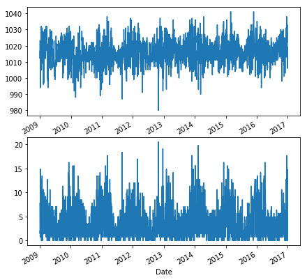

```
 Standard Deviation of Sea Level Press. (hPa) low
```

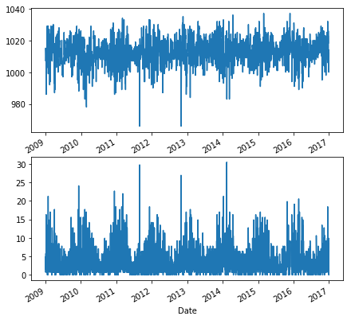

```
 Standard Deviation of Visibility (km) high
```

[7 more figures not shown]

```python
Std_Weather_Data = pd.DataFrame()
for columns in Weather_Data.iloc[:,0:19].columns:
    Std_Weather_Data[columns] = Weather_Data[columns].rolling(window=2,center=False).std()

for columns in Weather_Data.iloc[:,0:19].columns:
    print("\n","Standard Deviation of", columns)
    fig = plt.figure(figsize=(7,7))
    ax1 = plt.subplot2grid((2,1),(0,0))
    ax2 = plt.subplot2grid((2,1),(1,0))
    Weather_Data[columns].plot(ax=ax1)
    Std_Weather_Data[columns].plot(ax=ax2)
    plt.legend().remove()
    plt.legend().remove()
    plt.show()
```

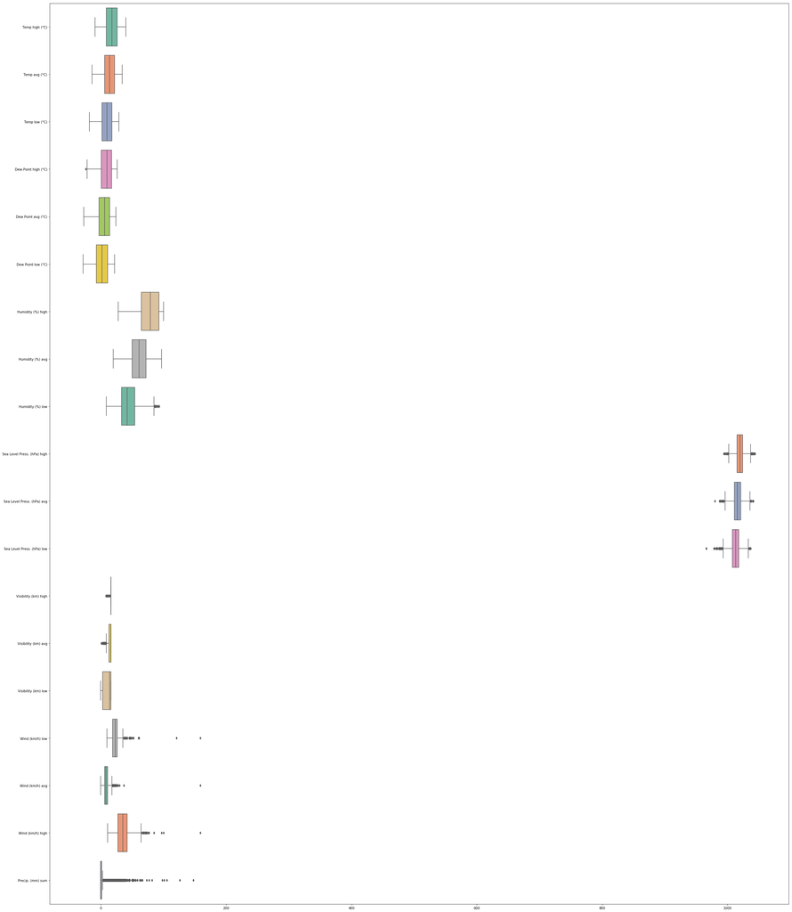

```python
plt.figure(figsize=(40,50))
sns.boxplot(data=Weather_Data,orient='h',palette="Set2")
plt.show()
```

```python
Weather_Data.shape
```

```
(2849, 19)
```

```python
Weather_Data.head(5)
```

| Date | Temp high (°C) | Temp avg (°C) | Temp low (°C) | Dew Point high (°C) | Dew Point avg (°C) | Dew Point low (°C) | Humidity (%) high | Humidity (%) avg | Humidity (%) low | Sea Level Press. (hPa) high | Sea Level Press. (hPa) avg | Sea Level Press. (hPa) low | Visibility (km) high | Visibility (km) avg | Visibility (km) low | Wind (km/h) low | Wind (km/h) avg | Wind (km/h) high | Precip. (mm) sum |
| --- | --- | --- | --- | --- | --- | --- | --- | --- | --- | --- | --- | --- | --- | --- | --- | --- | --- | --- | --- |
| 2009-01-01 | -3.0 | -6.0 | -9.0 | -16.0 | -17.0 | -19.0 | 54.0 | 43.0 | 32.0 | 1025.0 | 1023.0 | 1015.0 | 16.0 | 16.0 | 16.0 | 37.0 | 18.0 | 60.0 | 0.00 |
| 2009-01-02 | 1.0 | -2.0 | -5.0 | -3.0 | -7.0 | -17.0 | 78.0 | 57.0 | 36.0 | 1022.0 | 1012.0 | 1007.0 | 16.0 | 13.0 | 2.0 | 27.0 | 10.0 | 48.0 | 0.01 |
| 2009-01-03 | 3.0 | 1.0 | -2.0 | -5.0 | -9.0 | -13.0 | 72.0 | 54.0 | 35.0 | 1018.0 | 1015.0 | 1008.0 | 16.0 | 16.0 | 16.0 | 27.0 | 16.0 | 42.0 | 0.01 |
| 2009-01-04 | 6.0 | 1.0 | -4.0 | -10.0 | -12.0 | -13.0 | 55.0 | 42.0 | 29.0 | 1020.0 | 1017.0 | 1015.0 | 16.0 | 16.0 | 16.0 | 32.0 | 12.0 | 40.0 | 0.00 |
| 2009-01-05 | 6.0 | 5.0 | 3.0 | -1.0 | -5.0 | -16.0 | 62.0 | 48.0 | 33.0 | 1016.0 | 1014.0 | 1013.0 | 16.0 | 16.0 | 16.0 | 23.0 | 11.0 | 34.0 | 0.01 |

```python
##Resampling the weather data with the mean of each month
Weather_Data_mean = Weather_Data.resample('M').mean()
```

```python
#Rename columns so that they have no spaces
Weather_Data_mean.columns = ['Temphigh', 'Tempavg', 'Templow', 'DewPointhigh','DewPointavg','DewPointlow','Humidityhigh',
                        'Humidityavg','Humiditylow','SeaLevelPresshigh','SeaLevelPressavg','SeaLevelPresslow','Visibilityhigh',
                         'Visibilityavg', 'Visibilitylow','Windlow','Windavg','Windhigh','Precipsum']
Weather_Data_mean.head()
```

| Date | Temphigh | Tempavg | Templow | DewPointhigh | DewPointavg | DewPointlow | Humidityhigh | Humidityavg | Humiditylow | SeaLevelPresshigh | SeaLevelPressavg | SeaLevelPresslow | Visibilityhigh | Visibilityavg | Visibilitylow | Windlow | Windavg | Windhigh | Precipsum |
| --- | --- | --- | --- | --- | --- | --- | --- | --- | --- | --- | --- | --- | --- | --- | --- | --- | --- | --- | --- |
| 2009-01-31 | 0.741935 | -2.096774 | -5.322581 | -6.096774 | -9.903226 | -14.000000 | 71.774194 | 57.354839 | 42.322581 | 1021.290323 | 1015.967742 | 1010.516129 | 16.000000 | 14.000000 | 11.451613 | 27.000000 | 12.000000 | 39.322581 | 2.443226 |
| 2009-02-28 | 6.964286 | 2.785714 | -1.642857 | -2.464286 | -6.392857 | -10.571429 | 69.535714 | 54.000000 | 38.107143 | 1021.714286 | 1017.071429 | 1012.464286 | 16.000000 | 15.178571 | 13.285714 | 27.928571 | 12.214286 | 41.642857 | 0.781071 |
| 2009-03-31 | 9.838710 | 5.967742 | 1.774194 | 0.258065 | -2.903226 | -6.741935 | 74.096774 | 57.064516 | 39.548387 | 1025.096774 | 1021.064516 | 1017.032258 | 16.000000 | 14.258065 | 10.677419 | 27.000000 | 11.387097 | 38.612903 | 1.434194 |
| 2009-04-30 | 17.100000 | 12.733333 | 7.833333 | 6.233333 | 2.533333 | -1.200000 | 75.466667 | 55.700000 | 35.733333 | 1018.833333 | 1014.533333 | 1010.433333 | 15.900000 | 14.066667 | 10.866667 | 27.300000 | 11.366667 | 39.566667 | 3.971667 |
| 2009-05-31 | 20.931034 | 16.655172 | 12.206897 | 12.689655 | 9.827586 | 6.206897 | 85.827586 | 68.827586 | 51.413793 | 1020.448276 | 1017.241379 | 1014.172414 | 15.896552 | 12.275862 | 8.965517 | 22.379310 | 8.000000 | 32.620690 | 4.528276 |

```python
Weather_Data_mean.columns
```

```
Index(['Temphigh', 'Tempavg', 'Templow', 'DewPointhigh', 'DewPointavg',
       'DewPointlow', 'Humidityhigh', 'Humidityavg', 'Humiditylow',
       'SeaLevelPresshigh', 'SeaLevelPressavg', 'SeaLevelPresslow',
       'Visibilityhigh', 'Visibilityavg', 'Visibilitylow', 'Windlow',
       'Windavg', 'Windhigh', 'Precipsum'],
      dtype='object')
```

```python
Weather_Data_mean.shape
```

```
(96, 19)
```

```python
Train_Data.shape
```

```
(252, 2)
```

```python
Macroeconomic_Data.shape
```

```
(96, 15)
```

```python
EventHolidays_Data.shape
```

```
(96, 1)
```

# -------------------Data Preprocessing--------------

# Merging the DataFrames

Now,we had same shape(Number of rows) in all 3 Dataframes except Train Data. We will merge them before that we have to synchronise the Indexes of the dataframes

```python
# Synchronising the index before merging
EventHolidays_Data.index = Macroeconomic_Data.index
Weather_Data_mean.index = Macroeconomic_Data.index
```

```python
#Merging the data
Merged_Data = Macroeconomic_Data.join(Weather_Data_mean)
Merged_Data = Merged_Data.join(EventHolidays_Data)
```

```python
Merged_Data.shape
```

```
(96, 35)
```

```python
Merged_Data.head(5)
```

| Date | Monthly Nominal GDP Index (inMillion$) | Monthly Real GDP Index (inMillion$) | CPI | unemployment rate | CommercialBankInterestRateonCreditCardPlans | Finance Rate on Personal Loans at Commercial Banks, 24 Month Loan | Earnings or wages in dollars per hour | Cotton Monthly Price - US cents per Pound(lbs) | Change(in%) | Average upland planted(million acres) | ... | SeaLevelPressavg | SeaLevelPresslow | Visibilityhigh | Visibilityavg | Visibilitylow | Windlow | Windavg | Windhigh | Precipsum | DayCategory |
| --- | --- | --- | --- | --- | --- | --- | --- | --- | --- | --- | --- | --- | --- | --- | --- | --- | --- | --- | --- | --- | --- |
| 2009-01-01 | 14421.752895 | 14407.053343 | 233.402 | 7.8 | 12.03 | 11.44 | 22.05 | 57.70 | 4.02 | 9.296 | ... | 1015.967742 | 1010.516129 | 16.000000 | 14.000000 | 11.451613 | 27.000000 | 12.000000 | 39.322581 | 2.443226 | 8 |
| 2009-02-01 | 14389.200466 | 14366.176571 | 234.663 | 8.3 | 12.97 | 11.05 | 22.22 | 55.21 | -4.32 | 9.296 | ... | 1017.071429 | 1012.464286 | 16.000000 | 15.178571 | 13.285714 | 27.928571 | 12.214286 | 41.642857 | 0.781071 | 5 |
| 2009-03-01 | 14340.701639 | 14351.786822 | 235.067 | 8.7 | 12.97 | 11.05 | 22.22 | 51.50 | -6.72 | 9.296 | ... | 1021.064516 | 1017.032258 | 16.000000 | 14.258065 | 10.677419 | 27.000000 | 11.387097 | 38.612903 | 1.434194 | 0 |
| 2009-04-01 | 14326.815525 | 14351.601731 | 235.582 | 9.0 | 12.97 | 11.05 | 22.13 | 56.78 | 10.25 | 9.296 | ... | 1014.533333 | 1010.433333 | 15.900000 | 14.066667 | 10.866667 | 27.300000 | 11.366667 | 39.566667 | 3.971667 | 1 |
| 2009-05-01 | 14345.904809 | 14368.123959 | 235.975 | 9.4 | 13.32 | 11.25 | 22.04 | 61.95 | 9.11 | 9.297 | ... | 1017.241379 | 1014.172414 | 15.896552 | 12.275862 | 8.965517 | 22.379310 | 8.000000 | 32.620690 | 4.528276 | 5 |

5 rows × 35 columns

```python
#Merged_Data.to_csv("Preprocessed_Merged_Data1.csv")
```

correlation plot of Merged_Data

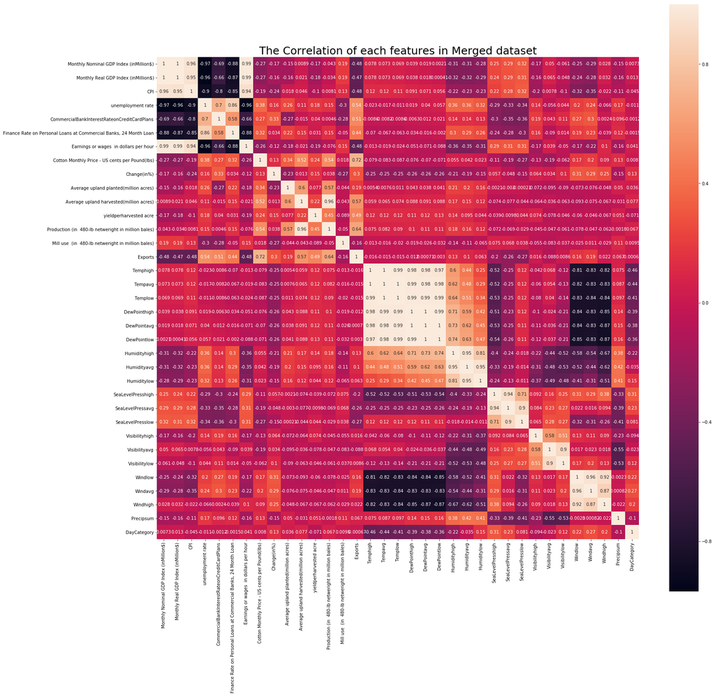

```python
correlation_merge = Merged_Data.corr()

### Ploting the correlation
%matplotlib inline
plt.figure(figsize =(25,25))
sns.heatmap(data= correlation_merge, annot =True, square= True)
plt.title('The Correlation of each features in Merged dataset', fontsize= '25')
plt.show()
```

Checking the top coorelated features having highest values

```python
def get_redundant_pairs(Merged_Data):
    '''Get diagonal and lower triangular pairs of correlation matrix'''
    pairs_to_drop = set()
    cols = Merged_Data.columns
    for i in range(0, Merged_Data.shape[1]):
        for j in range(0, i+1):
            pairs_to_drop.add((cols[i], cols[j]))
    return pairs_to_drop

def get_top_abs_correlations(Merged_Data, n=43):
    au_corr = Merged_Data.corr().abs().unstack()
    labels_to_drop = get_redundant_pairs(Merged_Data)
    au_corr = au_corr.drop(labels=labels_to_drop).sort_values(ascending=False)
    return au_corr[0:n]

print("Top Absolute Correlations")
print(get_top_abs_correlations(Merged_Data, 30))
```

```
Top Absolute Correlations
DewPointavg                              DewPointlow                                            0.998338
Temphigh                                 Tempavg                                                0.998249
Monthly Nominal GDP Index (inMillion$)   Monthly Real GDP Index (inMillion$)                    0.998172
DewPointhigh                             DewPointavg                                            0.997852
Tempavg                                  Templow                                                0.997823
DewPointhigh                             DewPointlow                                            0.993515
Temphigh                                 Templow                                                0.992269
Templow                                  DewPointhigh                                           0.991954
                                         DewPointavg                                            0.991014
Monthly Nominal GDP Index (inMillion$)   Earnings or wages  in dollars per hour                 0.988787
Tempavg                                  DewPointhigh                                           0.988145
Templow                                  DewPointlow                                            0.987319
Monthly Real GDP Index (inMillion$)      Earnings or wages  in dollars per hour                 0.985913
Tempavg                                  DewPointavg                                            0.984939
Temphigh                                 DewPointhigh                                           0.981194
Tempavg                                  DewPointlow                                            0.979246
Temphigh                                 DewPointavg                                            0.975859
Monthly Nominal GDP Index (inMillion$)   unemployment rate                                      0.968858
Temphigh                                 DewPointlow                                            0.968334
Monthly Real GDP Index (inMillion$)      unemployment rate                                      0.963478
Average upland harvested(million acres)  Production (in  480-lb netweright in million bales)    0.962632
unemployment rate                        Earnings or wages  in dollars per hour                 0.961626
Monthly Nominal GDP Index (inMillion$)   CPI                                                    0.960480
Windlow                                  Windavg                                                0.956209
Humidityavg                              Humiditylow                                            0.953193
Humidityhigh                             Humidityavg                                            0.949437
Monthly Real GDP Index (inMillion$)      CPI                                                    0.947941
CPI                                      Earnings or wages  in dollars per hour                 0.944291
SeaLevelPresshigh                        SeaLevelPressavg                                       0.937961
Windlow                                  Windhigh                                               0.924516
dtype: float64
```

# Splitting the data into Train, Test and Validation

Splitting the Target Variable into Train and Validation

I splitted data in such a way that from year 2009 to 2014 data goes under train data and Validation data includes year 2015 data

```python
split_validation_time = pd.to_datetime('2015-01-01')
split_test_time = pd.to_datetime('2016-01-01')
SalesTrain_Data.drop(SalesTrain_Data.columns[0],1,inplace = True)
```

```python
target_validation = SalesTrain_Data.loc[SalesTrain_Data.index >= split_validation_time]
target_train = SalesTrain_Data.loc[SalesTrain_Data.index < split_validation_time]
```

```python
target_train.head(5)
```

| Date | Sales(In ThousandDollars) |
| --- | --- |
| 2009-01-01 | 1755.0 |
| 2009-02-01 | 1729.0 |
| 2009-03-01 | 2256.0 |
| 2009-04-01 | 2662.0 |
| 2009-05-01 | 2732.0 |

```python
target_train.tail(5)
```

| Date | Sales(In ThousandDollars) |
| --- | --- |
| 2014-08-01 | 4067.0 |
| 2014-09-01 | 4481.0 |
| 2014-10-01 | 4434.0 |
| 2014-11-01 | 4525.0 |
| 2014-12-01 | 5664.0 |

```python
target_train.shape
```

```
(72, 1)
```

```python
target_validation.tail(5)
```

| Date | Sales(In ThousandDollars) |
| --- | --- |
| 2015-08-01 | 3897.0 |
| 2015-09-01 | 3881.0 |
| 2015-10-01 | 4372.0 |
| 2015-11-01 | 4401.0 |
| 2015-12-01 | 5874.0 |

```python
target_validation.shape
```

```
(12, 1)
```

```python
#Resampling the target_train data with the mean of each month
target_train_mean = target_train.resample('M').mean()
target_train_mean.shape
```

```
(72, 1)
```

```python
#Resampling the target_validation data with the mean of each month

target_validation_mean = target_validation.resample('M').mean()
target_validation_mean.shape
```

```
(12, 1)
```

Splitting the merged data into Train, Validation and Test

```python
Merged_Train = Merged_Data.loc[Merged_Data.index < split_validation_time]
Merged_Test = Merged_Data.loc[Merged_Data.index >= split_test_time]
Merged_Validation = Merged_Data.loc[(Merged_Data.index >= split_validation_time) \
                                             & (Merged_Data.index < split_test_time)]
```

```python
Merged_Train.tail(5)
```

| Date | Monthly Nominal GDP Index (inMillion$) | Monthly Real GDP Index (inMillion$) | CPI | unemployment rate | CommercialBankInterestRateonCreditCardPlans | Finance Rate on Personal Loans at Commercial Banks, 24 Month Loan | Earnings or wages in dollars per hour | Cotton Monthly Price - US cents per Pound(lbs) | Change(in%) | Average upland planted(million acres) | ... | SeaLevelPressavg | SeaLevelPresslow | Visibilityhigh | Visibilityavg | Visibilitylow | Windlow | Windavg | Windhigh | Precipsum | DayCategory |
| --- | --- | --- | --- | --- | --- | --- | --- | --- | --- | --- | --- | --- | --- | --- | --- | --- | --- | --- | --- | --- | --- |
| 2014-08-01 | 17684.635349 | 16196.420132 | 261.075 | 6.2 | 11.82 | 10.73 | 24.32 | 74.00 | -11.74 | 11.191 | ... | 1016.483871 | 1014.483871 | 16.000000 | 15.000000 | 11.806452 | 17.838710 | 5.967742 | 29.806452 | 1.843226 | 0 |
| 2014-09-01 | 17630.354586 | 16133.049427 | 261.074 | 5.9 | 11.82 | 10.73 | 24.50 | 73.38 | -0.84 | 10.818 | ... | 1019.300000 | 1016.133333 | 16.000000 | 14.900000 | 12.266667 | 19.166667 | 6.900000 | 30.500000 | 1.042000 | 4 |
| 2014-10-01 | 17709.436967 | 16196.814474 | 260.500 | 5.7 | 11.82 | 10.73 | 24.52 | 70.34 | -4.14 | 10.818 | ... | 1013.322581 | 1010.451613 | 16.000000 | 14.516129 | 10.064516 | 21.677419 | 8.322581 | 37.580645 | 4.998387 | 5 |
| 2014-11-01 | 17765.337570 | 16243.054734 | 259.382 | 5.8 | 11.99 | 10.47 | 24.78 | 67.53 | -3.99 | 10.818 | ... | 1017.400000 | 1012.833333 | 16.000000 | 14.300000 | 11.433333 | 22.733333 | 8.600000 | 37.800000 | 3.598667 | 8 |
| 2014-12-01 | 17733.024464 | 16221.180125 | 258.080 | 5.6 | 11.99 | 10.47 | 24.59 | 68.30 | 1.14 | 10.818 | ... | 1019.500000 | 1015.533333 | 15.666667 | 13.100000 | 9.566667 | 24.233333 | 10.900000 | 37.366667 | 5.038000 | 6 |

5 rows × 35 columns

```python
Merged_Train.shape
```

```
(72, 35)
```

```python
Merged_Validation.tail(5)
```

| Date | Monthly Nominal GDP Index (inMillion$) | Monthly Real GDP Index (inMillion$) | CPI | unemployment rate | CommercialBankInterestRateonCreditCardPlans | Finance Rate on Personal Loans at Commercial Banks, 24 Month Loan | Earnings or wages in dollars per hour | Cotton Monthly Price - US cents per Pound(lbs) | Change(in%) | Average upland planted(million acres) | ... | SeaLevelPressavg | SeaLevelPresslow | Visibilityhigh | Visibilityavg | Visibilitylow | Windlow | Windavg | Windhigh | Precipsum | DayCategory |
| --- | --- | --- | --- | --- | --- | --- | --- | --- | --- | --- | --- | --- | --- | --- | --- | --- | --- | --- | --- | --- | --- |
| 2015-08-01 | 18201.392888 | 16505.537615 | 261.347 | 5.1 | 12.10 | 9.80 | 25.04 | 71.82 | -0.73 | 8.750 | ... | 1015.225806 | 1013.516129 | 16.000000 | 15.354839 | 13.096774 | 18.548387 | 5.903226 | 30.451613 | 1.925484 | 0 |
| 2015-09-01 | 18317.816120 | 16601.489879 | 261.887 | 5.0 | 12.10 | 9.80 | 25.05 | 68.74 | -4.29 | 8.398 | ... | 1018.300000 | 1015.800000 | 15.766667 | 14.766667 | 11.933333 | 19.433333 | 7.033333 | 30.166667 | 2.777333 | 4 |
| 2015-10-01 | 18278.304270 | 16540.859723 | 261.515 | 5.0 | 12.10 | 9.80 | 25.14 | 69.03 | 0.42 | 8.398 | ... | 1018.935484 | 1015.709677 | 16.000000 | 15.161290 | 12.677419 | 21.258065 | 8.451613 | 34.258065 | 3.203871 | 5 |
| 2015-11-01 | 18266.244605 | 16524.199494 | 261.009 | 5.0 | 12.22 | 9.66 | 25.38 | 69.22 | 0.28 | 8.398 | ... | 1021.814815 | 1017.370370 | 16.000000 | 14.814815 | 12.333333 | 21.555556 | 7.777778 | 34.148148 | 1.871481 | 8 |
| 2015-12-01 | 18317.129125 | 16578.004544 | 259.941 | 5.0 | 12.22 | 9.66 | 25.21 | 70.39 | 1.69 | 8.398 | ... | 1018.142857 | 1012.666667 | 15.523810 | 12.333333 | 6.666667 | 23.000000 | 9.000000 | 35.761905 | 5.141905 | 7 |

5 rows × 35 columns

```python
Merged_Validation.shape
```

```
(12, 35)
```

```python
Merged_Test.tail(5)
```

| Date | Monthly Nominal GDP Index (inMillion$) | Monthly Real GDP Index (inMillion$) | CPI | unemployment rate | CommercialBankInterestRateonCreditCardPlans | Finance Rate on Personal Loans at Commercial Banks, 24 Month Loan | Earnings or wages in dollars per hour | Cotton Monthly Price - US cents per Pound(lbs) | Change(in%) | Average upland planted(million acres) | ... | SeaLevelPressavg | SeaLevelPresslow | Visibilityhigh | Visibilityavg | Visibilitylow | Windlow | Windavg | Windhigh | Precipsum | DayCategory |
| --- | --- | --- | --- | --- | --- | --- | --- | --- | --- | --- | --- | --- | --- | --- | --- | --- | --- | --- | --- | --- | --- |
| 2016-08-01 | 18741.599947 | 16797.206610 | 264.160 | 4.9 | 12.51 | 9.64 | 25.52 | 80.26 | -0.99 | 9.824 | ... | 1016.925926 | 1014.407407 | 15.925926 | 14.037037 | 9.037037 | 18.481481 | 6.037037 | 30.888889 | 1.844074 | 0 |
| 2016-09-01 | 18840.309646 | 16852.562745 | 264.602 | 4.9 | 12.51 | 9.64 | 25.74 | 77.86 | -2.99 | 9.950 | ... | 1018.965517 | 1016.517241 | 15.827586 | 14.000000 | 9.862069 | 20.689655 | 7.931034 | 33.655172 | 2.444138 | 4 |
| 2016-10-01 | 18740.780023 | 16725.460098 | 264.738 | 4.8 | 12.51 | 9.64 | 26.04 | 78.52 | 0.85 | 9.950 | ... | 1019.483871 | 1015.838710 | 15.935484 | 13.838710 | 10.000000 | 20.580645 | 7.419355 | 34.612903 | 3.400645 | 5 |
| 2016-11-01 | 18960.461568 | 16910.896330 | 265.203 | 4.6 | 12.41 | 9.45 | 25.87 | 78.92 | 0.51 | 9.950 | ... | 1017.000000 | 1013.600000 | 15.900000 | 14.366667 | 11.833333 | 22.300000 | 8.400000 | 36.800000 | 4.580000 | 9 |
| 2016-12-01 | 19015.393408 | 16918.050624 | 265.421 | 4.7 | 12.41 | 9.45 | 25.90 | 79.50 | 0.73 | 9.950 | ... | 1019.366667 | 1014.533333 | 16.000000 | 14.033333 | 10.166667 | 25.166667 | 10.000000 | 40.000000 | 2.448000 | 10 |

5 rows × 35 columns

```python
Merged_Test.shape
```

```
(12, 35)
```

```python
Merged_Data.dtypes
```

```
Monthly Nominal GDP Index (inMillion$)                               float64
Monthly Real GDP Index (inMillion$)                                  float64
CPI                                                                  float64
unemployment rate                                                    float64
CommercialBankInterestRateonCreditCardPlans                          float64
Finance Rate on Personal Loans at Commercial Banks, 24 Month Loan    float64
Earnings or wages  in dollars per hour                               float64
Cotton Monthly Price - US cents per Pound(lbs)                       float64
Change(in%)                                                          float64
Average upland planted(million acres)                                float64
Average upland harvested(million acres)                              float64
yieldperharvested acre                                                 int64
Production (in  480-lb netweright in million bales)                  float64
Mill use  (in  480-lb netweright in million bales)                   float64
Exports                                                              float64
Temphigh                                                             float64
Tempavg                                                              float64
Templow                                                              float64
DewPointhigh                                                         float64
DewPointavg                                                          float64
DewPointlow                                                          float64
Humidityhigh                                                         float64
Humidityavg                                                          float64
Humiditylow                                                          float64
SeaLevelPresshigh                                                    float64
SeaLevelPressavg                                                     float64
SeaLevelPresslow                                                     float64
Visibilityhigh                                                       float64
Visibilityavg                                                        float64
Visibilitylow                                                        float64
Windlow                                                              float64
Windavg                                                              float64
Windhigh                                                             float64
Precipsum                                                            float64
DayCategory                                                            int64
dtype: object
```

Normalizing the Merged_Data

Normalization rescales the values into a range of [0,1] This might be useful in some cases where all parameters need to have the same positive scale. so we need to normalize our data to be in same scale.

```python
#defining a normalisation function
def normalize (x):
    return ( (x-np.min(x))/ (max(x) - min(x)))
```

```python
# applying normalize ( ) to all columns
Merged_Train = Merged_Train.apply(normalize)
```

```python
#defining a normalisation function
def normalize (x):
    return ( (x-np.min(x))/ (max(x) - min(x)))
```

```python
# applying normalize ( ) to all columns
Merged_Validation = Merged_Validation.apply(normalize)
```

```python
#defining a normalisation function
def normalize (x):
    return ( (x-np.min(x))/ (max(x) - min(x)))
```

```python
# applying normalize ( ) to all columns
Merged_Test = Merged_Test.apply(normalize)
```

# Feature Selections

Data with very high dimensionality, models usually choke because Training time increases exponentially with number of features. Models have increasing risk of overfitting with increasing number of features. Feature Selection methods helps with these problems by reducing the dimensions without much loss of the total information. It also helps to make sense of the features and its importance. The objective of Feature selection is that it enables the machine learning algorithm to train faster. It reduces the complexity of a model and makes it easier to interpret. It improves the accuracy of a model if the right subset is chosen. It reduces overfitting.

```python
Merged_train_new = Merged_Train.copy()
Merged_test_new = Merged_Test.copy()
```

```python
Merged_train_new.shape,Merged_test_new.shape
```

```
((72, 35), (12, 35))
```

Removing Constant Features

```python
# remove constant features for train
constant_features = [
    feat for feat in Merged_Train.columns if Merged_Train[feat].std() == 0
]

Merged_Train.drop(labels=constant_features, axis=1, inplace=True)
Merged_Test.drop(labels=constant_features, axis=1, inplace=True)

Merged_Train.shape, Merged_Test.shape
```

```
((72, 35), (12, 35))
```

```python
# remove constant features for validation
constant_features = [
    feat for feat in Merged_Validation.columns if Merged_Validation[feat].std() == 0
]

Merged_Validation.drop(labels=constant_features, axis=1, inplace=True)
Merged_Test.drop(labels=constant_features, axis=1, inplace=True)

Merged_Validation.shape, Merged_Test.shape
```

```
((12, 35), (12, 35))
```

Remove Correlated features

```python
# find and remove correlated features from Merged_Train
def correlation(dataset, threshold):
    col_corr = set()  # Set of all the names of correlated columns
    corr_matrix = dataset.corr()
    for i in range(len(corr_matrix.columns)):
        for j in range(i):
            if abs(corr_matrix.iloc[i, j]) > threshold: # we are interested in absolute coeff value
                colname = corr_matrix.columns[i]  # getting the name of column
                col_corr.add(colname)
    return col_corr

corr_features = correlation(Merged_Train, 0.8)
print('correlated features: ', len(set(corr_features)), corr_features )
```

[output not shown]

```python
Merged_Train.drop(labels=corr_features, axis=1, inplace=True)
Merged_Test.drop(labels=corr_features, axis=1, inplace=True)

Merged_Train.shape, Merged_Test.shape
```

```
((72, 16), (12, 16))
```

```python
Merged_Validation.columns
```

```
Index(['Monthly Nominal GDP Index (inMillion$)',
       'Monthly Real GDP Index (inMillion$)', 'CPI', 'unemployment rate',
       'CommercialBankInterestRateonCreditCardPlans',
       'Finance Rate on Personal Loans at Commercial Banks, 24 Month Loan',
       'Earnings or wages  in dollars per hour',
       'Cotton Monthly Price - US cents per Pound(lbs)', 'Change(in%)',
       'Average upland planted(million acres)',
       'Average upland harvested(million acres)', 'yieldperharvested acre',
       'Production (in  480-lb netweright in million bales)',
       'Mill use  (in  480-lb netweright in million bales)', 'Exports',
       'Temphigh', 'Tempavg', 'Templow', 'DewPointhigh', 'DewPointavg',
       'DewPointlow', 'Humidityhigh', 'Humidityavg', 'Humiditylow',
       'SeaLevelPresshigh', 'SeaLevelPressavg', 'SeaLevelPresslow',
       'Visibilityhigh', 'Visibilityavg', 'Visibilitylow', 'Windlow',
       'Windavg', 'Windhigh', 'Precipsum', 'DayCategory'],
      dtype='object')
```

```python
Labels=['Monthly Real GDP Index (inMillion$)','CPI','unemployment rate','CommercialBankInterestRateonCreditCardPlans','Earnings or wages  in dollars per hour',
       'Production (in  480-lb netweright in million bales)','Tempavg', 'Templow', 'DewPointhigh', 'DewPointavg','DewPointlow', 'Humidityavg',
        'SeaLevelPressavg', 'SeaLevelPresslow','Visibilitylow', 'Windlow',
       'Windavg', 'Windhigh', 'Precipsum']
```

```python
Merged_Validation.drop(Labels, axis=1, inplace=True)
#Merged_Test.drop(Labels=corr_features, axis=1, inplace=True)

Merged_Validation.shape, Merged_Test.shape
```

```
((12, 16), (12, 16))
```

# Identifing Feature Importance using ANOVA

Anova's feature importnace is used to find a linear combination of features for one or more categorical independent features and one continuous dependent feature and it will let us know the significance of each feature in improving the model.

# ----Features Comparison---

```python
Sel = SelectKBest(k =5, score_func = f_regression)
Sel.fit(Merged_Train, target_train)
```

```
SelectKBest(k=5, score_func=<function f_regression at 0x0000018425546950>)
```

```python
 #creating imporatnce features for Merged_Train data
Important_features = []
importances = Sel.scores_
indices = np.argsort(importances)[::-1]
for f in range(Merged_Train.shape[1]):
    Important_features = np.append(Important_features, Merged_Train.columns.values[indices[f]])
```

```python
#checking the important_features obatined
Important_features
```

```
array(['Monthly Nominal GDP Index (inMillion$)',
       'Finance Rate on Personal Loans at Commercial Banks, 24 Month Loan',
       'Visibilityhigh', 'SeaLevelPresshigh', 'Exports',
       'Average upland planted(million acres)', 'Change(in%)',
       'Humidityhigh', 'Average upland harvested(million acres)',
       'Mill use  (in  480-lb netweright in million bales)',
       'Cotton Monthly Price - US cents per Pound(lbs)', 'Precipsum',
       'Visibilityavg', 'yieldperharvested acre', 'DayCategory',
       'Temphigh'], dtype='<U65')
```

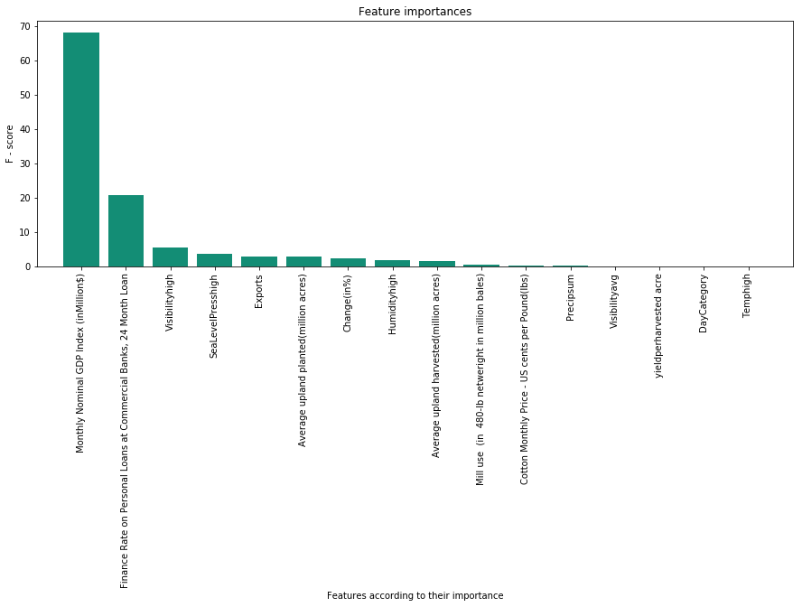

```python
#plotting bar plot of feature importance
plt.figure(figsize =(15,5))
plt.title("Feature importances")
plt.bar(range(Merged_Train.shape[1]), importances[indices],
       color="#138D75", align="center")
plt.xticks(range(Merged_Train.shape[1]), Important_features, rotation = 90)
plt.xlim([-1, Merged_Train.shape[1]])
plt.ylabel('F - score')
plt.xlabel('Features according to their importance')
plt.show()
```

# Checking for Multicolinearity using Variable Inflation Factor

In regression, "multicollinearity" refers to predictors that are correlated with other predictors. Multicollinearity occurs when your model includes multiple factors that are correlated not just to your response variable, but also to each other. So we use VIF to remove highly correlated predictors from the model.

```python
x_var = Merged_Train
y_var = target_train
x_var_names = Merged_Train.columns
for i in range(0, len(x_var_names)):
    y = x_var[x_var_names[i]]
    x = x_var[x_var_names.drop(x_var_names[i])]
    lr1 = LinearRegression()
    rsq = lr1.fit(x,y).score(x,y)
    vif = round(1/(1-rsq),2)
    print (x_var_names[i], " VIF = " , vif)
```

```
Monthly Nominal GDP Index (inMillion$)  VIF =  6.18
Finance Rate on Personal Loans at Commercial Banks, 24 Month Loan  VIF =  3.9
Cotton Monthly Price - US cents per Pound(lbs)  VIF =  2.76
Change(in%)  VIF =  1.68
Average upland planted(million acres)  VIF =  2.47
Average upland harvested(million acres)  VIF =  5.8
yieldperharvested acre  VIF =  1.79
Mill use  (in  480-lb netweright in million bales)  VIF =  1.3
Exports  VIF =  6.89
Temphigh  VIF =  4.27
Humidityhigh  VIF =  5.13
SeaLevelPresshigh  VIF =  1.92
Visibilityhigh  VIF =  1.94
Visibilityavg  VIF =  4.31
Precipsum  VIF =  1.85
DayCategory  VIF =  1.47
```

### Evaluation Metric used: MAPE(Mean Absolute Percentage Error)

The mean absolute percentage error (MAPE) is one of the most widely used measures of forecast accuracy, due to its advantages of scale-independency and interpretability. MAPE (Mean Absolute Percent Error) measures the size of the error in percentage terms which will help to find best Machine Learning model while forecasting the sales values. Model having Lowest MAPE value is to be considered to be best among the set of models.

```python
#defning mape value
def mean_absolute_percentage_error(y_true, y_pred):
    y_true, y_pred = np.array(y_true), np.array(y_pred)
    return np.mean(np.abs((y_true - y_pred) / y_true)) * 100
```

# --------------------Model Building-------------------

# 1) Linear Regression Model(OLS)

Ordinary Least Squares regression (OLS) is more commonly named linear regression (simple or multiple depending on the number of explanatory variables). If a model with p explanatory variables, the OLS regression model writes: Y = β0 + Σj=1..p βjXj + ε where Y is the dependent variable, β0, is the intercept of the model, X j corresponds to the jth explanatory variable of the model (j= 1 to p), and e is the random error with expectation 0 and variance σ². The OLS method corresponds to minimizing the sum of square differences between the observed and predicted values

```python
##Creating a OLS model
model1 = OLS(target_train,Merged_Train).fit()
OLS_Predicted_Train = model1.predict(Merged_Train)
print(model1.summary())
```

```
                                OLS Regression Results
=====================================================================================
Dep. Variable:     Sales(In ThousandDollars)   R-squared:                       0.971
Model:                                   OLS   Adj. R-squared:                  0.963
Method:                        Least Squares   F-statistic:                     118.9
Date:                       Fri, 15 Feb 2019   Prob (F-statistic):           3.28e-37
Time:                               23:02:36   Log-Likelihood:                -558.32
No. Observations:                         72   AIC:                             1149.
Df Residuals:                             56   BIC:                             1185.
Df Model:                                 16
Covariance Type:                   nonrobust
=====================================================================================================================================
                                                                        coef    std err          t      P>|t|      [0.025      0.975]
-------------------------------------------------------------------------------------------------------------------------------------
Monthly Nominal GDP Index (inMillion$)                             2942.1658    427.551      6.881      0.000    2085.678    3798.654
Finance Rate on Personal Loans at Commercial Banks, 24 Month Loan  1083.3348    475.536      2.278      0.027     130.721    2035.949
Cotton Monthly Price - US cents per Pound(lbs)                     -135.5457    612.334     -0.221      0.826   -1362.198    1091.106
Change(in%)                                                         336.3027    511.359      0.658      0.513    -688.072    1360.677
Average upland planted(million acres)                               -70.0043    367.668     -0.190      0.850    -806.532     666.523
Average upland harvested(million acres)                            -280.3895    400.612     -0.700      0.487   -1082.912     522.133
yieldperharvested acre                                             -323.1281    460.737     -0.701      0.486   -1246.096     599.840
Mill use  (in  480-lb netweright in million bales)                 -363.3926    455.461     -0.798      0.428   -1275.790     549.004
Exports                                                             815.0732    628.864      1.296      0.200    -444.692    2074.838
Temphigh                                                            108.5366    529.833      0.205      0.838    -952.847    1169.920
Humidityhigh                                                        276.3246    723.859      0.382      0.704   -1173.738    1726.387
SeaLevelPresshigh                                                   818.8037    454.195      1.803      0.077     -91.058    1728.665
Visibilityhigh                                                     -461.8619    361.120     -1.279      0.206   -1185.272     261.548
Visibilityavg                                                       815.5710    523.920      1.557      0.125    -233.966    1865.108
Precipsum                                                          1631.4347    618.077      2.640      0.011     393.277    2869.592
DayCategory                                                         236.0369    389.988      0.605      0.547    -545.203    1017.277
==============================================================================
Omnibus:                        7.394   Durbin-Watson:                   2.093
Prob(Omnibus):                  0.025   Jarque-Bera (JB):                8.875
Skew:                          -0.434   Prob(JB):                       0.0118
Kurtosis:                       4.485   Cond. No.                         25.8
==============================================================================

Warnings:
[1] Standard Errors assume that the covariance matrix of the errors is correctly specified.
```

We can see here that this model has a much higher R-squared value of 0.971, meaning that this model explains 97.1% of the variance in our dependent variable and this is a pretty high R². We can see that few features are statistically significant in predicting (or estimating) the sales value.

```python
#defning mape value
def mean_absolute_percentage_error(y_true, y_pred):
    y_true, y_pred = np.array(y_true), np.array(y_pred)
    return np.mean(np.abs((y_true - y_pred) / y_true)) * 100
```

```python
print(mean_absolute_percentage_error(target_train, OLS_Predicted_Train))
```

```
29.114515373889077
```

```python
#predicting on validation data
OLS_Predicted_Validation = model1.predict(Merged_Validation)
```

```python
print(mean_absolute_percentage_error(target_validation, OLS_Predicted_Validation))
```

```
38.1542704925968
```

```python
#predicting on Merged_test data
OLS_predicted_test = model1.predict(Merged_Test)
OLS_predicted_test
```

```
Date
2016-01-01    2352.097920
2016-02-01    2477.491017
2016-03-01    2286.780009
2016-04-01    3246.442690
2016-05-01    2466.763225
2016-06-01    2237.573659
2016-07-01    3803.583966
2016-08-01    2953.917351
2016-09-01    3935.753601
2016-10-01    4169.740435
2016-11-01    4902.351262
2016-12-01    4740.495738
Freq: MS, dtype: float64
```

```python
#converting predicted values into dataframe and renaming column
OLS_predicted_test = pd.DataFrame(OLS_predicted_test)
OLS_predicted_test = OLS_predicted_test.rename(columns = {OLS_predicted_test.columns[0]:'Sales(In ThousandDollars)'})
OLS_predicted_test
```

| Date | Sales(In ThousandDollars) |
| --- | --- |
| 2016-01-01 | 2352.097920 |
| 2016-02-01 | 2477.491017 |
| 2016-03-01 | 2286.780009 |
| 2016-04-01 | 3246.442690 |
| 2016-05-01 | 2466.763225 |
| 2016-06-01 | 2237.573659 |
| 2016-07-01 | 3803.583966 |
| 2016-08-01 | 2953.917351 |
| 2016-09-01 | 3935.753601 |
| 2016-10-01 | 4169.740435 |
| 2016-11-01 | 4902.351262 |
| 2016-12-01 | 4740.495738 |

```python
#resetting index as date and renaming as ID
OLS_predicted_test.reset_index('Date', inplace=True)
OLS_predicted_test=OLS_predicted_test.drop(['Date'],axis=1)
OLS_predicted_test.index.rename('ID',inplace =True)
OLS_predicted_test
```

| ID | Sales(In ThousandDollars) |
| --- | --- |
| 0 | 2352.097920 |
| 1 | 2477.491017 |
| 2 | 2286.780009 |
| 3 | 3246.442690 |
| 4 | 2466.763225 |
| 5 | 2237.573659 |
| 6 | 3803.583966 |
| 7 | 2953.917351 |
| 8 | 3935.753601 |
| 9 | 4169.740435 |
| 10 | 4902.351262 |
| 11 | 4740.495738 |

```python
### Reading the template file
final_result = pd.read_csv("NewSampleSubmission.csv")
final_result
```

|  | ID | Sales(In ThousandDollars) | Year | Month | ProductCategory |
| --- | --- | --- | --- | --- | --- |
| 0 | 1 | 110 | 2016 | 1 | WomenClothing |
| 1 | 2 | 140 | 2016 | 2 | WomenClothing |
| 2 | 3 | 199 | 2016 | 3 | WomenClothing |
| 3 | 4 | 246 | 2016 | 4 | WomenClothing |
| 4 | 5 | 66 | 2016 | 5 | WomenClothing |
| 5 | 6 | 201 | 2016 | 6 | WomenClothing |
| 6 | 7 | 225 | 2016 | 7 | WomenClothing |
| 7 | 8 | 69 | 2016 | 8 | WomenClothing |
| 8 | 9 | 216 | 2016 | 9 | WomenClothing |
| 9 | 10 | 247 | 2016 | 10 | WomenClothing |
| 10 | 11 | 184 | 2016 | 11 | WomenClothing |
| 11 | 12 | 113 | 2016 | 12 | WomenClothing |

```python
final_result=final_result.drop(['Sales(In ThousandDollars)'],axis=1)
final_result
```

|  | ID | Year | Month | ProductCategory |
| --- | --- | --- | --- | --- |
| 0 | 1 | 2016 | 1 | WomenClothing |
| 1 | 2 | 2016 | 2 | WomenClothing |
| 2 | 3 | 2016 | 3 | WomenClothing |
| 3 | 4 | 2016 | 4 | WomenClothing |
| 4 | 5 | 2016 | 5 | WomenClothing |
| 5 | 6 | 2016 | 6 | WomenClothing |
| 6 | 7 | 2016 | 7 | WomenClothing |
| 7 | 8 | 2016 | 8 | WomenClothing |
| 8 | 9 | 2016 | 9 | WomenClothing |
| 9 | 10 | 2016 | 10 | WomenClothing |
| 10 | 11 | 2016 | 11 | WomenClothing |
| 11 | 12 | 2016 | 12 | WomenClothing |

```python
ols_final_result=OLS_predicted_test.join(final_result)
ols_final_result
ols_final_result=ols_final_result.drop(['ID'],axis=1)
ols_final_result.index = ols_final_result.index + 1
ols_final_result
```

| ID | Sales(In ThousandDollars) | Year | Month | ProductCategory |
| --- | --- | --- | --- | --- |
| 1 | 2352.097920 | 2016 | 1 | WomenClothing |
| 2 | 2477.491017 | 2016 | 2 | WomenClothing |
| 3 | 2286.780009 | 2016 | 3 | WomenClothing |
| 4 | 3246.442690 | 2016 | 4 | WomenClothing |
| 5 | 2466.763225 | 2016 | 5 | WomenClothing |
| 6 | 2237.573659 | 2016 | 6 | WomenClothing |
| 7 | 3803.583966 | 2016 | 7 | WomenClothing |
| 8 | 2953.917351 | 2016 | 8 | WomenClothing |
| 9 | 3935.753601 | 2016 | 9 | WomenClothing |
| 10 | 4169.740435 | 2016 | 10 | WomenClothing |
| 11 | 4902.351262 | 2016 | 11 | WomenClothing |
| 12 | 4740.495738 | 2016 | 12 | WomenClothing |

```python
#saving predicted file to specific current working directory location
ols_final_result.to_csv("OLS_prediction.csv")
```

# Checking for the Residuals v/s Fitted plot

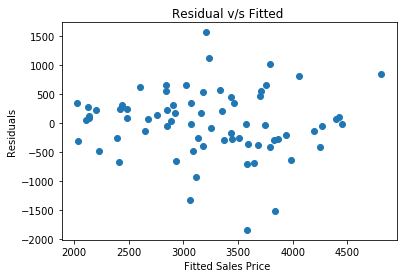

```python
plt.scatter(model1.fittedvalues, model1.resid)
plt.xlabel('Fitted Sales Price ')
plt.ylabel('Residuals')
plt.title('Residual v/s Fitted ')
plt.show()
```

# Checking for Hetroscedasticity

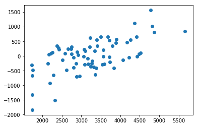

```python
# Heteroscedasticity
plt.scatter(target_train,model1.resid)
plt.show()
```

Converting all the train, validation and test data into array format and scaling them.

```python
X_train = np.array(Merged_Train)
X_train = preprocessing.scale(X_train)

X_val = np.array(Merged_Validation)
X_val = preprocessing.scale(X_val)

X_test = np.array(Merged_Test)
X_test = preprocessing.scale(Merged_Test)

Y_train = np.array(target_train[target_train.columns[0]]).ravel()
Y_val = np.array(target_validation[target_validation.columns[0]]).ravel()
```

# Ridge Regression Model

As the model complexity, which in the case of linear regression can be thought of as the number of predictors increases, estimates' variance also increases, but the bias decreases. Hence we choose Ridge Regression, the OLS loss function is augmented in such a way that we not only minimize the sum of squared residuals but also penalize the size of parameter estimates, in order to shrink them towards zero.

```python
# list of alphas to tune
params = {'alpha': [0.0001, 0.001, 0.01, 0.05, 0.1,
 0.2, 0.3, 0.4, 0.5, 0.6, 0.7, 0.8, 0.9, 1.0, 2.0, 3.0,
 4.0, 5.0, 6.0, 7.0, 8.0, 9.0, 10.0, 20, 50, 100, 500, 1000 ]}

#
ridge = Ridge()

# cross validation
folds = 5
model_cv = GridSearchCV(estimator = ridge,
                        param_grid = params,
                        scoring= 'neg_mean_absolute_error',
                        cv = folds,
                        return_train_score=True,
                        verbose = 1)
model_cv.fit(X_train, Y_train)
```

```
Fitting 5 folds for each of 28 candidates, totalling 140 fits
```

```
[Parallel(n_jobs=1)]: Done 140 out of 140 | elapsed:    0.3s finished
```

```
GridSearchCV(cv=5, error_score='raise',
       estimator=Ridge(alpha=1.0, copy_X=True, fit_intercept=True, max_iter=None,
   normalize=False, random_state=None, solver='auto', tol=0.001),
       fit_params=None, iid=True, n_jobs=1,
       param_grid={'alpha': [0.0001, 0.001, 0.01, 0.05, 0.1, 0.2, 0.3, 0.4, 0.5, 0.6, 0.7, 0.8, 0.9, 1.0, 2.0, 3.0, 4.0, 5.0, 6.0, 7.0, 8.0, 9.0, 10.0, 20, 50, 100, 500, 1000]},
       pre_dispatch='2*n_jobs', refit=True, return_train_score=True,
       scoring='neg_mean_absolute_error', verbose=1)
```

```python
cv_results = pd.DataFrame(model_cv.cv_results_)
cv_results.head()
```

|  | mean_fit_time | std_fit_time | mean_score_time | std_score_time | param_alpha | params | split0_test_score | split1_test_score | split2_test_score | split3_test_score | ... | mean_test_score | std_test_score | rank_test_score | split0_train_score | split1_train_score | split2_train_score | split3_train_score | split4_train_score | mean_train_score | std_train_score |
| --- | --- | --- | --- | --- | --- | --- | --- | --- | --- | --- | --- | --- | --- | --- | --- | --- | --- | --- | --- | --- | --- |
| 0 | 0.001198 | 3.997347e-04 | 0.000600 | 0.000490 | 0.0001 | {'alpha': 0.0001} | -605.057061 | -645.571981 | -581.102686 | -704.047407 | ... | -733.883313 | 208.146377 | 27 | -451.168950 | -406.618700 | -380.586385 | -362.663944 | -365.510799 | -393.309756 | 32.859234 |
| 1 | 0.000999 | 5.091228e-07 | 0.000400 | 0.000490 | 0.001 | {'alpha': 0.001} | -604.940822 | -645.578799 | -581.023906 | -704.010945 | ... | -733.825367 | 208.147608 | 26 | -451.168144 | -406.618977 | -380.584616 | -362.662217 | -365.508848 | -393.308560 | 32.859762 |
| 2 | 0.001399 | 4.897461e-04 | 0.000800 | 0.000400 | 0.01 | {'alpha': 0.01} | -603.782170 | -645.646365 | -580.238312 | -703.647779 | ... | -733.247730 | 208.160496 | 25 | -451.160054 | -406.621757 | -380.566989 | -362.645003 | -365.489360 | -393.296632 | 32.865012 |
| 3 | 0.001199 | 3.997096e-04 | 0.001000 | 0.000001 | 0.05 | {'alpha': 0.05} | -598.713247 | -645.933369 | -576.794747 | -702.064960 | ... | -730.719692 | 208.230247 | 24 | -451.123494 | -406.634455 | -380.490047 | -362.569734 | -365.403205 | -393.244187 | 32.887760 |
| 4 | 0.001200 | 3.993767e-04 | 0.000599 | 0.000489 | 0.1 | {'alpha': 0.1} | -592.555820 | -646.263210 | -572.597399 | -700.154814 | ... | -727.646712 | 208.344219 | 23 | -451.087848 | -406.651050 | -380.396990 | -362.478361 | -365.298396 | -393.182529 | 32.918590 |

5 rows × 21 columns

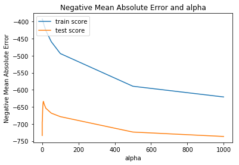

```python
# plotting mean test and train scoes with alpha
cv_results['param_alpha'] = cv_results['param_alpha'].astype('int32')

# plotting
plt.plot(cv_results['param_alpha'], cv_results['mean_train_score'])
plt.plot(cv_results['param_alpha'], cv_results['mean_test_score'])
plt.xlabel('alpha')
plt.ylabel('Negative Mean Absolute Error')
plt.title("Negative Mean Absolute Error and alpha")
plt.legend(['train score', 'test score'], loc='upper left')
plt.show()
```

```python
#choosing alpha value  as 100
alpha = 100
ridge = Ridge(alpha=alpha)

ridge.fit(X_train, Y_train)
ridge.coef_
```

```
array([190.31857403, -96.1273116 ,  18.84826538, -30.58713676,
        17.86192305,  50.84868322, -15.14729973,   6.12211607,
       -31.34029649,   5.87948463, -44.17035715,  53.6497216 ,
       -66.11609091,  -5.88443199,  29.73301564,   2.41032968])
```

```python
ridge_predictions = ridge.predict(X_train)
```

```python
print(mean_absolute_percentage_error(Y_train, ridge_predictions))
```

```
17.248443598136753
```

```python
ridge_validation = ridge.predict(X_val)
print(mean_absolute_percentage_error(Y_val,ridge_validation))
```

```
25.305581842039597
```

```python
ridge_predicted_test = ridge.predict(X_test)
ridge_predicted_test
```

```
array([3089.91898957, 2765.77058836, 2831.25260544, 2861.83052275,
       3140.88861663, 3121.11555778, 3304.21283126, 3310.71328866,
       3505.23403771, 3376.98823333, 3720.31222806, 3720.0637557 ])
```

```python
ridge_predicted_test = pd.DataFrame(ridge_predicted_test)
ridge_predicted_test
```

|  | 0 |
| --- | --- |
| 0 | 3089.918990 |
| 1 | 2765.770588 |
| 2 | 2831.252605 |
| 3 | 2861.830523 |
| 4 | 3140.888617 |
| 5 | 3121.115558 |
| 6 | 3304.212831 |
| 7 | 3310.713289 |
| 8 | 3505.234038 |
| 9 | 3376.988233 |
| 10 | 3720.312228 |
| 11 | 3720.063756 |

```python
### Reading the template file
final_result_ridge = pd.read_csv("NewSampleSubmission.csv")

final_result_ridge = final_result_ridge.loc[final_result_ridge.ProductCategory == "WomenClothing",].copy()
```

```python
final_result_ridge = final_result_ridge.join(ridge_predicted_test)
```

```python
final_result_ridge.head(3)
```

|  | ID | Sales(In ThousandDollars) | Year | Month | ProductCategory | 0 |
| --- | --- | --- | --- | --- | --- | --- |
| 0 | 1 | 110 | 2016 | 1 | WomenClothing | 3089.918990 |
| 1 | 2 | 140 | 2016 | 2 | WomenClothing | 2765.770588 |
| 2 | 3 | 199 | 2016 | 3 | WomenClothing | 2831.252605 |

```python
final_modified_ridge=final_result_ridge.drop(['Sales(In ThousandDollars)','Year','Month','ProductCategory'],axis=1)
```

```python
final_modified_ridge.head(3)
```

|  | ID | 0 |
| --- | --- | --- |
| 0 | 1 | 3089.918990 |
| 1 | 2 | 2765.770588 |
| 2 | 3 | 2831.252605 |

```python
final_modified_ridge = final_modified_ridge.rename(columns = {final_modified_ridge.columns[1]:'Sales(In ThousandDollars)'})
```

```python
#final_ridge = final_modified_ridge.join(final_result_sub)
#final_ridge.head(3)
```

```python
#final_ridge.index = final_ridge.index + 1
#final_ridge.index.rename('ID',inplace =True)
```

```python
#final_ridge=final_ridge.drop(["ID"],axis=1)
#final_ridge.head(3)
```

```python
#final_ridge.to_csv("prediction_Ridge.csv")
```

# Xgboost Model

XGBoost is well known to provide better solutions than other machine learning algorithms. XGBoost is also known as ‘regularized boosting‘ technique which reduces overfitting. So lets apply and check evaluation of model.

```python
from sklearn.ensemble import RandomForestRegressor
import xgboost as xgb
```

```python
xgb_model = xgb.XGBRegressor()
xgb_model.fit(X_train, Y_train)

pred = xgb_model.predict(X_train)
pred
```

```
array([1691.6613, 1753.815 , 2357.7927, 2660.1199, 2711.6917, 2273.7102,
       2221.579 , 2351.1013, 2383.1868, 2493.8716, 2629.3506, 3269.3015,
       2228.0505, 2485.7568, 3012.592 , 1872.3662, 3094.8428, 2745.4258,
       2715.982 , 2837.217 , 2893.1409, 3059.786 , 3276.75  , 4252.138 ,
       2276.8271, 2687.2917, 3337.1287, 3315.966 , 3320.7275, 3198.0698,
       2935.1128, 3246.269 , 3123.508 , 2017.2288, 3484.8645, 4713.738 ,
       2326.048 , 2829.608 , 3537.166 , 3569.2373, 3767.9392, 3119.8894,
       2975.8179, 2993.6978, 2003.0975, 3160.0786, 3506.5588, 4655.1685,
       2393.9104, 2953.9038, 3695.9934, 3826.7354, 4084.2036, 3364.2495,
       3333.3457, 3514.304 , 3702.129 , 3641.4255, 3819.9587, 4889.3423,
       2936.6501, 3368.1824, 4285.8057, 4245.3228, 4393.098 , 3894.2446,
       3784.438 , 4054.752 , 4447.5366, 4374.8267, 4542.311 , 5543.2764],
      dtype=float32)
```

```python
print(mean_absolute_percentage_error(Y_train, pred))
```

```
2.057941500614961
```

```python
pred_validation = xgb_model.predict(X_val)
print(mean_absolute_percentage_error(Y_val, pred_validation))
```

```
30.67261411084666
```

```python
xgb_predicted_test = xgb_model.predict(X_test)
xgb_predicted_test
```

```
array([2408.8276, 2312.8262, 2629.182 , 3158.3481, 3438.8394, 3144.997 ,
       3118.6768, 3263.9998, 3383.1736, 3104.2764, 4241.1924, 3327.147 ],
      dtype=float32)
```

```python
xgb_predicted_test = pd.DataFrame(xgb_predicted_test)
```

```python
xgb_predicted_test
```

|  | 0 |
| --- | --- |
| 0 | 2408.827637 |
| 1 | 2312.826172 |
| 2 | 2629.181885 |
| 3 | 3158.348145 |
| 4 | 3438.839355 |
| 5 | 3144.997070 |
| 6 | 3118.676758 |
| 7 | 3263.999756 |
| 8 | 3383.173584 |
| 9 | 3104.276367 |
| 10 | 4241.192383 |
| 11 | 3327.146973 |

```python
### Reading the template file
final_result_sub = pd.read_csv("NewSampleSubmission.csv")

final_result_xgb = final_result_sub.loc[final_result_sub.ProductCategory == "WomenClothing",].copy()
final_result_xgb.head(3)
```

|  | ID | Sales(In ThousandDollars) | Year | Month | ProductCategory |
| --- | --- | --- | --- | --- | --- |
| 0 | 1 | 110 | 2016 | 1 | WomenClothing |
| 1 | 2 | 140 | 2016 | 2 | WomenClothing |
| 2 | 3 | 199 | 2016 | 3 | WomenClothing |

```python
final_result_xgb = final_result_sub.join(xgb_predicted_test)
final_result_xgb.head(3)
```

|  | ID | Sales(In ThousandDollars) | Year | Month | ProductCategory | 0 |
| --- | --- | --- | --- | --- | --- | --- |
| 0 | 1 | 110 | 2016 | 1 | WomenClothing | 2408.827637 |
| 1 | 2 | 140 | 2016 | 2 | WomenClothing | 2312.826172 |
| 2 | 3 | 199 | 2016 | 3 | WomenClothing | 2629.181885 |

```python
final_modified_xgb=final_result_xgb.drop(['Sales(In ThousandDollars)','Year','Month','ProductCategory'],axis=1)
final_modified_xgb.head(12)
```

|  | ID | 0 |
| --- | --- | --- |
| 0 | 1 | 2408.827637 |
| 1 | 2 | 2312.826172 |
| 2 | 3 | 2629.181885 |
| 3 | 4 | 3158.348145 |
| 4 | 5 | 3438.839355 |
| 5 | 6 | 3144.997070 |
| 6 | 7 | 3118.676758 |
| 7 | 8 | 3263.999756 |
| 8 | 9 | 3383.173584 |
| 9 | 10 | 3104.276367 |
| 10 | 11 | 4241.192383 |
| 11 | 12 | 3327.146973 |

```python
final_modified_xgb = final_modified_xgb.rename(columns = {final_modified_xgb.columns[1]:'Sales(In ThousandDollars)'})
final_modified_xgb.head(3)
```

|  | ID | Sales(In ThousandDollars) |
| --- | --- | --- |
| 0 | 1 | 2408.827637 |
| 1 | 2 | 2312.826172 |
| 2 | 3 | 2629.181885 |

```python
#final_xgb = final_modified_xgb.join(final_result_xgb)
#final_xgb.head(3)
```

# RANDOM FOREST MODEL

A Random Forest is an ensemble technique capable of performing both regression and classification tasks with the use of multiple decision trees and a technique called Bootstrap Aggregation, commonly known as bagging.Ensemble methods like Random forest run many decision trees and aggregate their outputs for prediction. This process controls for overfitting and can often produce a very robust, high-performing model. Random forests and some other boosting methods are easy, that I often use early in the modeling process to see how they perform with my data. Also, they have a super helpful feature called feature importances.

```python
# Random Forest
rf = RandomForestRegressor(bootstrap=True, criterion='mae', max_depth=None,
           max_features='auto', max_leaf_nodes=None, min_impurity_decrease=0.0,
           min_impurity_split=None, min_samples_leaf=1,
           min_samples_split=2, min_weight_fraction_leaf=0.0,
           n_estimators=1000, n_jobs=1, oob_score=False, random_state=None,
           verbose=0, warm_start=False)
rf_predicted_train = rf.fit(Merged_Train,target_train).predict(Merged_Train)

print(mean_absolute_percentage_error(target_train,rf_predicted_train))
rf_predicted_val = rf.predict(Merged_Validation)
print(mean_absolute_percentage_error(target_validation,rf_predicted_val))
```

```
29.44265242415526
27.8859906666309
```

```python
rf_predicted_test = rf.predict(Merged_Test)
rf_predicted_test = pd.DataFrame(rf_predicted_test)
```

```python
rf_predicted_test
```

|  | 0 |
| --- | --- |
| 0 | 2215.481372 |
| 1 | 2081.068121 |
| 2 | 3041.269226 |
| 3 | 2976.497485 |
| 4 | 3315.029109 |
| 5 | 3093.824071 |
| 6 | 3671.989046 |
| 7 | 3179.132326 |
| 8 | 3241.810067 |
| 9 | 3198.482297 |
| 10 | 4112.436833 |
| 11 | 4428.620410 |

Hyperparameter Tuning

```python
# RandomForest with cross validation
parameter_value = {'min_samples_leaf':[1,5,10,50,100,200,500],'n_estimators':[100,200,300,400,500]}
rf_grid = GridSearchCV(estimator= RandomForestRegressor(),param_grid=parameter_value, n_jobs=-1)

rf_grid_predicted_train = rf_grid.fit(Merged_Train,target_train).predict(Merged_Train)

print(mean_absolute_percentage_error(target_train,rf_grid_predicted_train))
rf_grid_predicted_val = rf_grid.predict(Merged_Validation)
print(mean_absolute_percentage_error(target_validation,rf_grid_predicted_val))
```

```
27.449885199443397
24.42856192551649
```

```python
rf_grid.best_estimator_
```

```
RandomForestRegressor(bootstrap=True, criterion='mse', max_depth=None,
           max_features='auto', max_leaf_nodes=None,
           min_impurity_decrease=0.0, min_impurity_split=None,
           min_samples_leaf=10, min_samples_split=2,
           min_weight_fraction_leaf=0.0, n_estimators=200, n_jobs=1,
           oob_score=False, random_state=None, verbose=0, warm_start=False)
```

```python
rf_grid_predicted_test = rf_grid.predict(Merged_Test)
rf_grid_predicted_test = pd.DataFrame(rf_grid_predicted_test)
```

```python
rf_grid_predicted_test
```

|  | 0 |
| --- | --- |
| 0 | 2723.349321 |
| 1 | 2498.748822 |
| 2 | 3015.636681 |
| 3 | 3253.041553 |
| 4 | 3331.288476 |
| 5 | 3184.095145 |
| 6 | 3225.592488 |
| 7 | 3635.628048 |
| 8 | 3785.588423 |
| 9 | 3664.358892 |
| 10 | 3934.775805 |
| 11 | 3929.898167 |

```python
rf_grid_predicted_test = rf_grid_predicted_test.rename(columns = {rf_grid_predicted_test.columns[0]:'Sales(In ThousandDollars)'})
rf_grid_predicted_test
```

|  | Sales(In ThousandDollars) |
| --- | --- |
| 0 | 2723.349321 |
| 1 | 2498.748822 |
| 2 | 3015.636681 |
| 3 | 3253.041553 |
| 4 | 3331.288476 |
| 5 | 3184.095145 |
| 6 | 3225.592488 |
| 7 | 3635.628048 |
| 8 | 3785.588423 |
| 9 | 3664.358892 |
| 10 | 3934.775805 |
| 11 | 3929.898167 |

```python
rf_grid_predicted_test.index.rename('ID',inplace =True)
rf_grid_predicted_test
```

| ID | Sales(In ThousandDollars) |
| --- | --- |
| 0 | 2723.349321 |
| 1 | 2498.748822 |
| 2 | 3015.636681 |
| 3 | 3253.041553 |
| 4 | 3331.288476 |
| 5 | 3184.095145 |
| 6 | 3225.592488 |
| 7 | 3635.628048 |
| 8 | 3785.588423 |
| 9 | 3664.358892 |
| 10 | 3934.775805 |
| 11 | 3929.898167 |

```python
### Reading the template file
final_result = pd.read_csv("NewSampleSubmission.csv")
final_result
```

|  | ID | Sales(In ThousandDollars) | Year | Month | ProductCategory |
| --- | --- | --- | --- | --- | --- |
| 0 | 1 | 110 | 2016 | 1 | WomenClothing |
| 1 | 2 | 140 | 2016 | 2 | WomenClothing |
| 2 | 3 | 199 | 2016 | 3 | WomenClothing |
| 3 | 4 | 246 | 2016 | 4 | WomenClothing |
| 4 | 5 | 66 | 2016 | 5 | WomenClothing |
| 5 | 6 | 201 | 2016 | 6 | WomenClothing |
| 6 | 7 | 225 | 2016 | 7 | WomenClothing |
| 7 | 8 | 69 | 2016 | 8 | WomenClothing |
| 8 | 9 | 216 | 2016 | 9 | WomenClothing |
| 9 | 10 | 247 | 2016 | 10 | WomenClothing |
| 10 | 11 | 184 | 2016 | 11 | WomenClothing |
| 11 | 12 | 113 | 2016 | 12 | WomenClothing |

```python
final_result=final_result.drop(['Sales(In ThousandDollars)','ID'],axis=1)
final_result
```

|  | Year | Month | ProductCategory |
| --- | --- | --- | --- |
| 0 | 2016 | 1 | WomenClothing |
| 1 | 2016 | 2 | WomenClothing |
| 2 | 2016 | 3 | WomenClothing |
| 3 | 2016 | 4 | WomenClothing |
| 4 | 2016 | 5 | WomenClothing |
| 5 | 2016 | 6 | WomenClothing |
| 6 | 2016 | 7 | WomenClothing |
| 7 | 2016 | 8 | WomenClothing |
| 8 | 2016 | 9 | WomenClothing |
| 9 | 2016 | 10 | WomenClothing |
| 10 | 2016 | 11 | WomenClothing |
| 11 | 2016 | 12 | WomenClothing |

```python
rf_grid_predicted_result=rf_grid_predicted_test.join(final_result)
rf_grid_predicted_result
```

| ID | Sales(In ThousandDollars) | Year | Month | ProductCategory |
| --- | --- | --- | --- | --- |
| 0 | 2723.349321 | 2016 | 1 | WomenClothing |
| 1 | 2498.748822 | 2016 | 2 | WomenClothing |
| 2 | 3015.636681 | 2016 | 3 | WomenClothing |
| 3 | 3253.041553 | 2016 | 4 | WomenClothing |
| 4 | 3331.288476 | 2016 | 5 | WomenClothing |
| 5 | 3184.095145 | 2016 | 6 | WomenClothing |
| 6 | 3225.592488 | 2016 | 7 | WomenClothing |
| 7 | 3635.628048 | 2016 | 8 | WomenClothing |
| 8 | 3785.588423 | 2016 | 9 | WomenClothing |
| 9 | 3664.358892 | 2016 | 10 | WomenClothing |
| 10 | 3934.775805 | 2016 | 11 | WomenClothing |
| 11 | 3929.898167 | 2016 | 12 | WomenClothing |

```python
rf_grid_predicted_result=rf_grid_predicted_result.index + 1
rf_grid_predicted_result
```

```
RangeIndex(start=1, stop=13, step=1, name='ID')
```

```python
#rf_grid_predicted_result.to_csv("rf_grid_prediction1.csv")
```

Checking feature importance using Random forest regressor

```python
important_features = []
importances = rf.feature_importances_
indices = np.argsort(importances)[::-1]
print("*************************************")
print("*                                   *")
print("*      Ranking of the features      *")
print("*                                   *")
print("*************************************")
for f in range(Merged_Train.shape[1]):
    print("%d. %s (%f)" % (f+1, Merged_Train.columns.values[indices[f]], importances[indices[f]]))
    important_features = np.append(important_features, Merged_Train.columns.values[indices[f]])
```

```
*                                   *
*      Ranking of the features      *
*                                   *
1. Monthly Nominal GDP Index (inMillion$) (0.399390)
2. Temphigh (0.060005)
3. Visibilityavg (0.056020)
4. Humidityhigh (0.052197)
5. Change(in%) (0.050130)
6. SeaLevelPresshigh (0.045902)
7. yieldperharvested acre (0.044353)
8. Cotton Monthly Price - US cents per Pound(lbs) (0.043747)
9. Exports (0.042254)
10. DayCategory (0.038783)
11. Visibilityhigh (0.036087)
12. Mill use  (in  480-lb netweright in million bales) (0.030776)
13. Precipsum (0.027946)
14. Average upland planted(million acres) (0.025999)
15. Average upland harvested(million acres) (0.025341)
16. Finance Rate on Personal Loans at Commercial Banks, 24 Month Loan (0.021072)
```

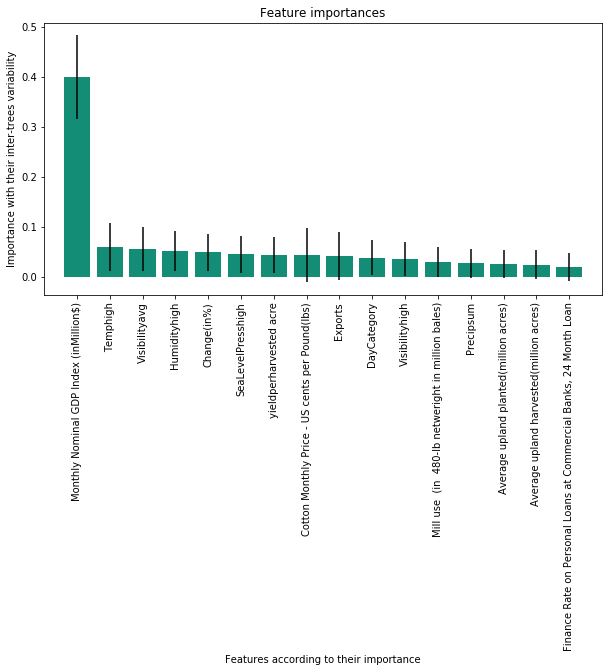

```python
std = np.std([tree.feature_importances_ for tree in rf.estimators_], axis=0)
plt.figure(figsize =(10,5))
plt.title("Feature importances")
plt.bar(range(Merged_Train.shape[1]), importances[indices],
       color="#138D75", yerr=std[indices], align="center")
plt.xticks(range(Merged_Train.shape[1]), important_features, rotation = 90)
plt.xlim([-1, Merged_Train.shape[1]])
plt.ylabel('Importance with their inter-trees variability')
plt.xlabel('Features according to their importance')
plt.show()
```

# -------------------------------End of Regression Analysis ---------------------------------------------------------------------------------------------------------------------------------------------

# ----------------Sales Forecasting using Time Series Analysis------------------------

# Importing Required packages

```python
from pandas import Series
from matplotlib import pyplot
from statsmodels.tsa.seasonal import seasonal_decompose
import warnings
import itertools
import numpy as np
import matplotlib.pyplot as plt
warnings.filterwarnings("ignore")
plt.style.use('fivethirtyeight')
import pandas as pd
import statsmodels.api as sm
import matplotlib
matplotlib.rcParams['axes.labelsize'] = 14
matplotlib.rcParams['xtick.labelsize'] = 12
matplotlib.rcParams['ytick.labelsize'] = 12
matplotlib.rcParams['text.color'] = 'k'
```

# Loading the Data File and Basic Understanding of Data

```python
#Reading the Data
SalesData=pd.read_csv("Train.csv")
```

```python
SalesData.head(5)
```

|  | Year | Month | ProductCategory | Sales(In ThousandDollars) |
| --- | --- | --- | --- | --- |
| 0 | 2009 | 1 | WomenClothing | 1755.0 |
| 1 | 2009 | 1 | MenClothing | 524.0 |
| 2 | 2009 | 1 | OtherClothing | 936.0 |
| 3 | 2009 | 2 | WomenClothing | 1729.0 |
| 4 | 2009 | 2 | MenClothing | 496.0 |

```python
SalesData.tail(5)
```

|  | Year | Month | ProductCategory | Sales(In ThousandDollars) |
| --- | --- | --- | --- | --- |
| 247 | 2015 | 11 | MenClothing | 643.0 |
| 248 | 2015 | 11 | OtherClothing | 1478.0 |
| 249 | 2015 | 12 | WomenClothing | 5874.0 |
| 250 | 2015 | 12 | MenClothing | 967.0 |
| 251 | 2015 | 12 | OtherClothing | 1680.0 |

```python
SalesData.describe(include='all')
```

|  | Year | Month | ProductCategory | Sales(In ThousandDollars) |
| --- | --- | --- | --- | --- |
| count | 252.00000 | 252.000000 | 252 | 239.000000 |
| unique | NaN | NaN | 3 | NaN |
| top | NaN | NaN | MenClothing | NaN |
| freq | NaN | NaN | 84 | NaN |
| mean | 2012.00000 | 6.500000 | NaN | 1746.602510 |
| std | 2.00398 | 3.458922 | NaN | 1300.395559 |
| min | 2009.00000 | 1.000000 | NaN | 471.000000 |
| 25% | 2010.00000 | 3.750000 | NaN | 714.000000 |
| 50% | 2012.00000 | 6.500000 | NaN | 1136.000000 |
| 75% | 2014.00000 | 9.250000 | NaN | 2803.500000 |
| max | 2015.00000 | 12.000000 | NaN | 5874.000000 |

```python
#checking the datatypes
SalesData.dtypes
```

```
Year                           int64
Month                          int64
ProductCategory               object
Sales(In ThousandDollars)    float64
dtype: object
```